# Homework 3 (Deep Neural Network)

- 截止日期：2020/12/15 18:00前（當天上課前）
- 繳交格式：

  ```
    | --HW3_學號_姓名.zip
        |-- Hw3_學號_姓名.ipynb
  ```

- 繳交檔案時請將debug、紀錄或測試用的檔案刪除(如：.ipynb_checkpoints)
- 請將輸出結果儲存，以便作業檢查
- 若有參考書面或網路資訊，請附上書名或連結，沒付上參考資料者視同剽竊，本作業以0分記
- 請使用`markdown`區塊描述作法或填寫問題

## Homework 3-1 : 實作感知器(區分or邏輯)

1. 請將所有有含問號`?`的函式補齊，使程式能夠正常運作

   > `forward`、`activation` 、`backward`
2. 請呼叫main函數，並填入epoch與learning rate，並依照下面要求答題
   > - 請將epoch分別固定在2500，測試至少3種不同的learning rate
   > - 請將learning rate分別固定在.01，測試至少3種不同的epoch
3. 請寫下你覺得調整epoch跟learning rate所造成的影響

參考資訊：

1. 【書籍】Python 機器學習錦囊妙計
2. 【書籍】Data Science From Scratch
3. 【網頁】https://l.facebook.com/l.php?u=https%3A%2F%2Fwww.kdnuggets.com%2F2018%2F10%2Fsimple-neural-network-python.html%3Ffbclid%3DIwAR0HGarr8ELYt43FkRDa00XgxcnbY8AxPyl5NTXE0r8DbgmixFKnMlbkJDg&h=AT1GxNejBRmZnRSRAWrUFKEmg5FFWWdZdRVcUfQvMGBS9kdfgoxbKE_St3hKURWewPlD99nDEOHrTKAYesNgDUJXpv_PLrFPMFxm1FZKw5Gq6AuGeQMYdeeekByHsa8ACK4cOBQvg2A0ewI
4. 【網頁】https://colab.research.google.com/github/casperbh96/Neural-Network-From-Scratch/blob/master/NN_From_Scratch.ipynb
5. 【網頁】https://github.com/dennybritz/nn-from-scratch/blob/master/nn-from-scratch.ipynb
6. 【網頁】https://l.facebook.com/l.php?u=http%3A%2F%2Fneuralnetworksanddeeplearning.com%2Fchap2.html%3Ffbclid%3DIwAR2hRIbah5XCX5Nw9-1sy2LLxd0-ZzyWEzLf7dzwOpobmMU5dCO8SP0DdEM&h=AT0brscxaWBHRQO_XTuhch1uCb3euP1PIfgbIC_C-6ZW2z1LsI_9QNy29hez_5jHtW00Fafkb4LUyn1_hQ95Tlz7iQwmOTayE7m7ZUpmfZFBhisnkxZS6DUlYVOheO8c5SxEloPG0k-7-Ac

```python
import numpy as np
import matplotlib.pylab as plt
```

### Part 1

請將所有有含問號?的函式補齊，使程式能夠正常運作

```python
#前傳遞=>如同計算 y =ax+b
def forward(Input_X, weight, bias):
    y_matrix = np.dot(Input_X, weight) + bias #將矩陣相乘
    Predict_Y = activation(y_matrix) #進入活化函數做大小調整
    return Predict_Y
```

```python
#活化函數
def activation(s):
    output_value = 1 / (1 + np.exp(-s)) # 請實作sigmmoid function
    return output_value
```

```python
def activation_derivation(s):
    # 看書中說明表示因為NN會一直把最小的值給h，但擔心會因為四捨五入太多次之後會有計算上的誤差，所以用這個方式來逼近
    h = 1e-5
    return (activation(s+h) - activation(s)) / h
#return activation(s) * (1 - activation(s))
```

```python
# 倒傳遞演算法
def backward(Input_X, Output_Y, Predict_Y, weight, learning_rate, error_history):
    output_error = Predict_Y - Output_Y.reshape(Input_X.shape[0], 1) #計算誤差
    # 有時候會出現無限大的值，所以當出現的時候就取其他值的平均
    if output_error[0] == np.inf:
        output_error[0] = np.mean(output_error[1:])
    error_history.append(np.mean(np.sqrt(np.square(output_error)))) #將Mean Square Error 加入error_history
    z_delt = output_error * activation_derivation(Predict_Y)
    weight += -learning_rate * np.dot(Input_X.T, z_delt) #更新weight，學習率*delta，注意"本次實作沒有隱藏層"
    return weight
```

```python
#訓練函數
def train(Input_X, Output_Y ,bias, weight, learning_rate, error_history):
    o_matrix = forward(Input_X, weight, bias)
    weight = backward(Input_X, Output_Y, o_matrix, weight, learning_rate, error_history)
    return weight
```

```python
def predict(xPredicted, weight, bias, show_details=True):
    if show_details:
        print("Predict data\n" + str(xPredicted))
        print('----------------------')
        print("Output_rate: \n" + str(forward(xPredicted, weight, bias)))
```

```python
def result_show(weight, bias, epoch, error_history, learning_rate, show_details=True):
    #此區不用修改，僅為顯示結果用
    #最後的輸出結果為:
    if show_details:
        print('最後的weight為:')
        print(weight)
        print('----------------')
    #開始預測不同輸入的結果,此為4組 00 01 10 11
    xPredicted = np.array(([0,0], [0,1], [1,0], [1,1]), dtype=float)
    predict(xPredicted, weight, bias, show_details=show_details)#開始預測
    if show_details:
        print('----------------')
        print('最後的loss為:')
        print(error_history[-1])

    plt.plot(np.arange(0, epoch, 1), np.array(error_history), label = 'mean square error')
    plt.title(f'learning rate: {learning_rate}, epoch: {epoch}')
    plt.xlabel('epoch')
    plt.ylabel('error_history')
    plt.legend()
    plt.show()
```

```python
def main(epoch, learning_rate, show_details=True):
    #主程式開始
    #設定所有資訊
    Input_X = np.array(([0, 0],
                        [0, 1],
                        [1, 0],
                        [1, 1]), dtype=float)#輸入資訊 總共兩維資訊
    Input_size = 2#輸入的維度為多少  此為2
    Output_Y = np.array(([0],
                         [1],
                         [1],
                         [1]), dtype=float)#輸入資訊後應該要有的預期結果
    Output_size = 1#輸出的維度為多少  此為1
    bias=0
    error_history = []#用來記錄每次誤差值
    weight = np.random.randn(Input_size, Output_size)# np.random.randn =>依照常態分配的機率隨機取一個值
    if show_details:
        print('最初的weight為:')
        print(weight) #查看一開始亂數產生的weight
    #開始依照每一代做訓練
    for i in range(epoch):
        weight = train(Input_X, Output_Y, bias, weight, learning_rate, error_history)
    #顯示結果
    result_show(weight, bias, epoch, error_history, learning_rate, show_details=show_details)
```

### Part 2

請呼叫main函數，填入epoch與learning rate，並依照下面要求答題

> - 請將epoch固定在2500，測試至少3種不同的learning rate
> - 請將learning rate固定在.01，測試至少3種不同的epoch

測試不同參數時，可將每次的數值差距拉大，以利觀察結果變化

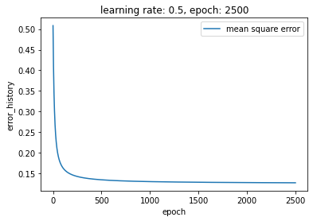

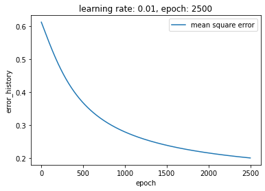

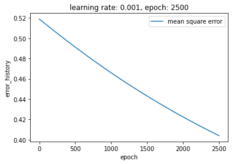

```python
learning_rate = [0.5, 0.01, 0.001]
for lr in learning_rate:
    main(epoch=2500, learning_rate=lr, show_details=False)
```

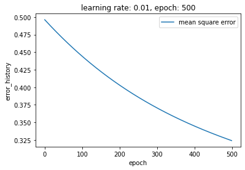

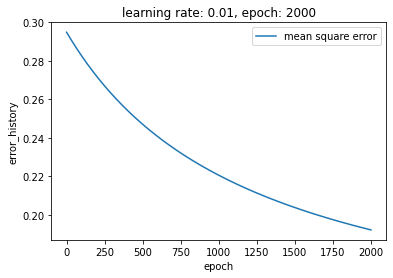

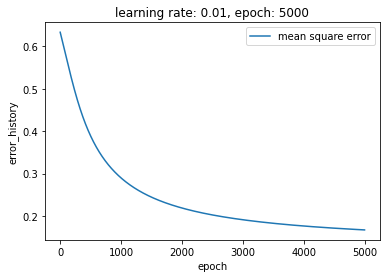

```python
epochs = [500, 2000, 5000]
for epoch in epochs:
    main(epoch, learning_rate=0.01, show_details=False)
```

### Part 3

請寫下你覺得調整epoch跟learning rate所造成的影響

learning rate 太大的時候一開始loss就有可能一下到很低，但過沒多久epochs之後loss就可能下不去了，到不了minima；

而learning rate 太小的話，每次都往低處走很小步，所以可能需要很多的epochs才會到minima

## install all needed dependencies

```python
import numpy as np
import pandas as pd
import seaborn as sns
import missingno as msno
!pip install fancyimpute
from fancyimpute import KNN, IterativeImputer
from sklearn.preprocessing import StandardScaler
from keras.utils import np_utils
```

```
     |████████████████████████████████| 154 kB 42.1 MB/s
```

## Homework 3-2 : DNN / ML

作業說明：

> 作業3-2使用[Kaggle Titanic](https://www.kaggle.com/c/titanic/overview) 所提供的資料集，本資料集分為train.csv以及test.csv，請用train.csv建構模型及預測生還者。test.csv中沒有答案，加分題需使用test.csv並上傳至[Kaggle Titanic](https://www.kaggle.com/c/titanic/overview)進行評分。

### Part 0 讀取檔案

請在此區塊後使用**一個或多個區塊**進行讀取檔案，項目**至少**包含：

- 以`pd.read_csv()`讀取檔案
- 以`pd.head()`顯示前5筆資料
- 以`pd.info()`顯示資料型態與大小

請以 `markdown` 簡單描述各變項的意思

```python
from google.colab import drive
drive.mount('/content/drive')
```

```python
PATH_TRAIN = '/content/drive/MyDrive/機器深度學習導論/train.csv'
print(PATH_TRAIN)
```

```
/content/drive/MyDrive/機器深度學習導論/train.csv
```

```python
df = pd.read_csv(PATH_TRAIN)
df.head()
```

|  | PassengerId | Survived | Pclass | Name | Sex | Age | SibSp | Parch | Ticket | Fare | Cabin | Embarked |
| --- | --- | --- | --- | --- | --- | --- | --- | --- | --- | --- | --- | --- |
| 0 | 1 | 0 | 3 | Braund, Mr. Owen Harris | male | 22.0 | 1 | 0 | A/5 21171 | 7.2500 | NaN | S |
| 1 | 2 | 1 | 1 | Cumings, Mrs. John Bradley (Florence Briggs Th... | female | 38.0 | 1 | 0 | PC 17599 | 71.2833 | C85 | C |
| 2 | 3 | 1 | 3 | Heikkinen, Miss. Laina | female | 26.0 | 0 | 0 | STON/O2. 3101282 | 7.9250 | NaN | S |
| 3 | 4 | 1 | 1 | Futrelle, Mrs. Jacques Heath (Lily May Peel) | female | 35.0 | 1 | 0 | 113803 | 53.1000 | C123 | S |
| 4 | 5 | 0 | 3 | Allen, Mr. William Henry | male | 35.0 | 0 | 0 | 373450 | 8.0500 | NaN | S |

```python
df.info()
```

```
<class 'pandas.core.frame.DataFrame'>
RangeIndex: 891 entries, 0 to 890
Data columns (total 12 columns):
 #   Column       Non-Null Count  Dtype
---  ------       --------------  -----
 0   PassengerId  891 non-null    int64
 1   Survived     891 non-null    int64
 2   Pclass       891 non-null    int64
 3   Name         891 non-null    object
 4   Sex          891 non-null    object
 5   Age          714 non-null    float64
 6   SibSp        891 non-null    int64
 7   Parch        891 non-null    int64
 8   Ticket       891 non-null    object
 9   Fare         891 non-null    float64
 10  Cabin        204 non-null    object
 11  Embarked     889 non-null    object
dtypes: float64(2), int64(5), object(5)
memory usage: 83.7+ KB
```

```python
# how many missing data on each column
df.isnull().sum()
```

```
PassengerId      0
Survived         0
Pclass           0
Name             0
Sex              0
Age            177
SibSp            0
Parch            0
Ticket           0
Fare             0
Cabin          687
Embarked         2
dtype: int64
```

```python
# how many people did or did not survived
df.Survived.value_counts()
```

```
0    549
1    342
Name: Survived, dtype: int64
```

### Part 1 資料分析與前處理

請在此區塊後使用**一個或多個區塊**進行資料分析與前處理，項目**至少**包含：

- 處理**缺失值**
- 將**類別**資料進行**one-hot encoding**
- 繪製**數值**資料的**直方圖**查看資料分布
- 整合資料(將處理完的資料重整並分成train_x及train_y)

其他可額外增加的項目：

- 相關係數
- 決定輸入特徵
- 其他資料視覺化
- 其他

請以 `markdown` 簡單描述每個項目的**想法**、**方法**與**原因**：

例如：

1. 觀察...，發現...
2. 填補...，策略...
3. 轉換...，原因...

#### data visualization

```
array([[<matplotlib.axes._subplots.AxesSubplot object at 0x7fc347171850>,
      dtype=object)
```

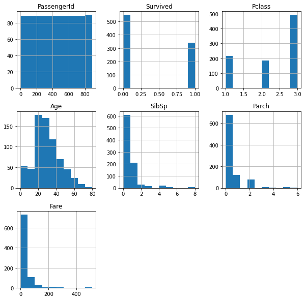

```python
df.hist(figsize=(10, 10))
```

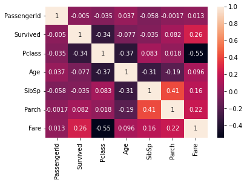

```python
sns.heatmap(df.corr(), annot=True)
```

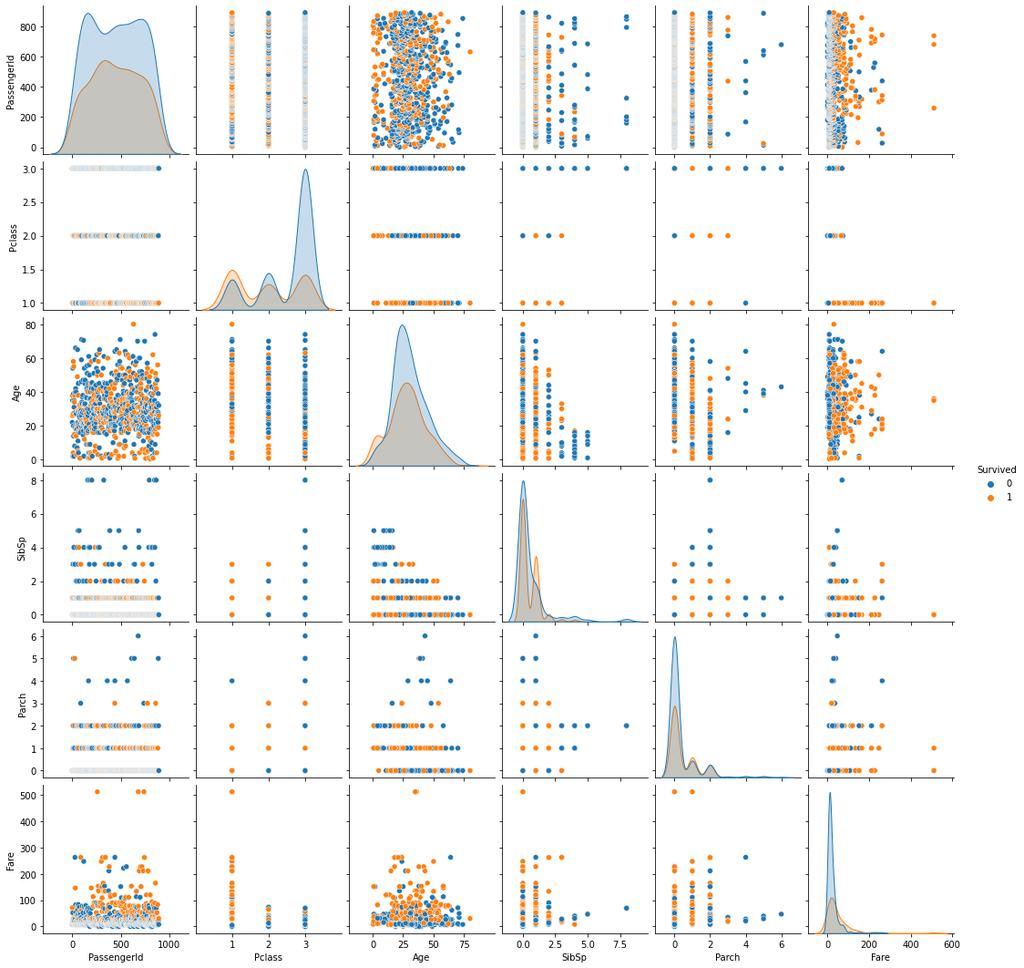

```python
sns.pairplot(df, hue='Survived')
```

#### Deal with missing data & impute with KNN

```python
msno.matrix(df)
```

[output not shown]

```python
msno.heatmap(df)
```

[output not shown]

```python
df_sex_embarked = df[['Sex', 'Embarked']]
df_sex_embarked_dummy = pd.get_dummies(df_sex_embarked)
#df_sex_embarked_dummy
```

```python
df_rest = df[['Survived', 'Pclass', 'Age', 'SibSp', 'Parch', 'Fare']]
#df_rest
```

```python
df_to_impute = pd.concat([df_sex_embarked_dummy, df_rest], axis=1)
#df_to_impute
```

```python
cols = [col for col in df_to_impute.columns]
#cols
```

```python
imputer = KNN(k=3)
df_imputed = pd.DataFrame(imputer.fit_transform(df_to_impute), columns=cols)
```

```
Imputing row 1/891 with 0 missing, elapsed time: 0.182
Imputing row 101/891 with 0 missing, elapsed time: 0.184
Imputing row 201/891 with 0 missing, elapsed time: 0.186
Imputing row 301/891 with 1 missing, elapsed time: 0.187
Imputing row 401/891 with 0 missing, elapsed time: 0.188
Imputing row 501/891 with 0 missing, elapsed time: 0.190
Imputing row 601/891 with 0 missing, elapsed time: 0.193
Imputing row 701/891 with 0 missing, elapsed time: 0.194
Imputing row 801/891 with 0 missing, elapsed time: 0.195
```

```python
df_imputed
```

|  | Sex_female | Sex_male | Embarked_C | Embarked_Q | Embarked_S | Survived | Pclass | Age | SibSp | Parch | Fare |
| --- | --- | --- | --- | --- | --- | --- | --- | --- | --- | --- | --- |
| 0 | 0.0 | 1.0 | 0.0 | 0.0 | 1.0 | 0.0 | 3.0 | 22.000000 | 1.0 | 0.0 | 7.2500 |
| 1 | 1.0 | 0.0 | 1.0 | 0.0 | 0.0 | 1.0 | 1.0 | 38.000000 | 1.0 | 0.0 | 71.2833 |
| 2 | 1.0 | 0.0 | 0.0 | 0.0 | 1.0 | 1.0 | 3.0 | 26.000000 | 0.0 | 0.0 | 7.9250 |
| 3 | 1.0 | 0.0 | 0.0 | 0.0 | 1.0 | 1.0 | 1.0 | 35.000000 | 1.0 | 0.0 | 53.1000 |
| 4 | 0.0 | 1.0 | 0.0 | 0.0 | 1.0 | 0.0 | 3.0 | 35.000000 | 0.0 | 0.0 | 8.0500 |
| ... | ... | ... | ... | ... | ... | ... | ... | ... | ... | ... | ... |
| 886 | 0.0 | 1.0 | 0.0 | 0.0 | 1.0 | 0.0 | 2.0 | 27.000000 | 0.0 | 0.0 | 13.0000 |
| 887 | 1.0 | 0.0 | 0.0 | 0.0 | 1.0 | 1.0 | 1.0 | 19.000000 | 0.0 | 0.0 | 30.0000 |
| 888 | 1.0 | 0.0 | 0.0 | 0.0 | 1.0 | 0.0 | 3.0 | 16.980366 | 1.0 | 2.0 | 23.4500 |
| 889 | 0.0 | 1.0 | 1.0 | 0.0 | 0.0 | 1.0 | 1.0 | 26.000000 | 0.0 | 0.0 | 30.0000 |
| 890 | 0.0 | 1.0 | 0.0 | 1.0 | 0.0 | 0.0 | 3.0 | 32.000000 | 0.0 | 0.0 | 7.7500 |

891 rows × 11 columns

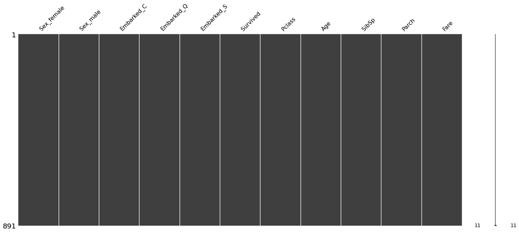

```python
msno.matrix(df_imputed)
```

#### x-y preparation

```python
# features & target
train_x = df_imputed[['Sex_female', 'Sex_male', 'Embarked_C', 'Embarked_Q', 'Embarked_S', 'Pclass', 'Age', 'SibSp', 'Parch', 'Fare']]
train_y = df_imputed[['Survived']]
```

```python
scaler = StandardScaler()
train_x_standardized = scaler.fit_transform(train_x)
train_y_onehot = np_utils.to_categorical(train_y)
```

### Part2 模型建構、執行與結果呈現

請在此區塊後使用**一個或多個區塊**進行**DNN模型**和括號內**任一其他模型**(KNN、SVM、tree-based)訓練，**需要**包含以下內容：

- **DNN模型**
  - 設定模型**超參數**
  - 利用`summary()`顯示模型架構
- 計算**準確度（Accuracy）**
  - 使用 **5-fold cross validation**，輸出**平均準確度**
  - 最後再使用**所有**資料進行訓練並輸出**準確度**
- 將**訓練過程**利用畫圖套件視覺化
  - 使用**所有**資料進行訓練的**準確度**變化繪製準確度變化圖
  - 使用**所有**資料進行訓練的**Loss**變化繪製損失率變化圖
- 檢驗訓練結果
  - 繪製**混淆矩陣**
  - 繪製**ROC曲線**並計算**auc score**
- **其他任一模型**
  - 設定模型**超參數**
- 檢驗訓練結果
  - 輸出**準確度**

```python
from keras import models, layers, regularizers, metrics
!pip install tensorflow_addons
import tensorflow_addons as tfa
from keras.utils.vis_utils import plot_model
from keras.callbacks import EarlyStopping
from sklearn.model_selection import KFold
from sklearn.metrics import roc_curve, roc_auc_score, accuracy_score, precision_score, f1_score, balanced_accuracy_score
from sklearn.ensemble import RandomForestClassifier
from sklearn.svm import SVC
```

#### DNN with k-fold

```python
METRICS = [
    'accuracy'#,
    #metrics.Precision(name='precision', thresholds=0.7),
    #tfa.metrics.F1Score(num_classes=2)
]

number_of_features = train_x.shape[1]
```

```python
# setting up early stopping
early_stopping = EarlyStopping(monitor='val_accuracy',
                               min_delta=0.01,
                               patience=300,
                               verbose=1,
                               mode='max')
```

```python
# build network
activation_1 = 'relu'
activation_2 = 'sigmoid'

network = models.Sequential()
network.add(layers.Dense(units=9, activation=activation_1, input_dim=number_of_features))
network.add(layers.Dense(units=30, activation=activation_1))
network.add(layers.Dense(units=30, activation=activation_1))
# adding L2 regularizer to some layers
network.add(layers.Dense(units=30, activation=activation_1, kernel_regularizer=regularizers.l2(0.01)))
network.add(layers.Dense(units=30, activation=activation_1))
network.add(layers.Dense(units=2, activation=activation_2))

network.compile(
    loss='binary_crossentropy', # method to count loss
    optimizer='rmsprop',
    metrics=METRICS) # method to evaluate the network
```

```python
# apply k-fold
kf = KFold(n_splits=5, random_state=48, shuffle=True)
kf.get_n_splits(train_x_standardized)
train_acc_list = []
count = 1
```

```python
# train network on k-fold & its average accuracy
for train_index, valid_index in kf.split(train_x):
    train_x_split = train_x.iloc[train_index]
    train_y_split = train_y_onehot[train_index]
    valid_x_split = train_x.iloc[valid_index]
    valid_y_split = train_y_onehot[valid_index]

    network.fit(train_x,
                train_y_onehot,
                epochs=10000,
                verbose=0,
                validation_data=(valid_x_split, valid_y_split),
                callbacks=[early_stopping])
    train_acc = network.evaluate(train_x_split, train_y_split)
    train_acc_list.append(train_acc[1])
    print(f'{count}/5')
    count += 1

print(f'average train accuracy: {np.mean(train_acc_list)}')
```

```
Epoch 00802: early stopping
1/5
Epoch 00347: early stopping
2/5
Epoch 00670: early stopping
3/5
Epoch 00334: early stopping
4/5
Epoch 00307: early stopping
5/5
average train accuracy: 0.8897300601005554
```

#### DNN with full data

```python
# build network
activation_1 = 'relu'
activation_2 = 'sigmoid'

network = models.Sequential()
network.add(layers.Dense(units=9, activation=activation_1, input_dim=number_of_features))
network.add(layers.Dense(units=30, activation=activation_1))
network.add(layers.Dense(units=30, activation=activation_1))
network.add(layers.Dense(units=30, activation=activation_1, kernel_regularizer=regularizers.l2(0.01)))
network.add(layers.Dense(units=30, activation=activation_1))
network.add(layers.Dense(units=2, activation=activation_2))

network.compile(
    loss='binary_crossentropy',
    optimizer='rmsprop',
    metrics=METRICS)
```

```python
history = network.fit(train_x,
                      train_y_onehot,
                      epochs=10000,
                      verbose=0,
                      validation_data=(train_x, train_y_onehot),
                      callbacks=[early_stopping])
```

```
Epoch 01730: early stopping
```

##### model evaluation

```python
train_loss, train_accuracy = network.evaluate(train_x, train_y_onehot)
print("-"*80)
print(f"train loss: {train_loss}, train acc: {train_accuracy}")
```

```
--------------------------------------------------------------------------------
train loss: 0.18233752250671387, train acc: 0.9371492862701416
```

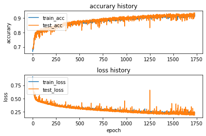

```python
# training & testing accuracy
plt.subplot(211)

plt.plot(history.history['accuracy'])
plt.plot(history.history['val_accuracy'])
plt.ylabel("accurary")
plt.title("accurary history")
plt.legend(['train_acc','test_acc'], loc='upper left')

# training & testing loss
plt.subplot(212)

plt.plot(history.history['loss'])
plt.plot(history.history['val_loss'])
plt.ylabel("loss")
plt.title("loss history")
plt.legend(['train_loss', 'test_loss'], loc='upper left')
plt.xlabel("epoch")

plt.tight_layout()
plt.show()
```

```python
# model prediction's label on training data
y_hat_predictions_label = np.argmax(network.predict(train_x), axis=1)
#y_hat_predictions_label
```

[output not shown]

[output cut: 26 more lines]

```python
# confusion matrix
confusion = pd.crosstab(np.argmax(train_y_onehot, axis=1),
                        y_hat_predictions_label,
                        rownames=['true'],
                        colnames=['predict'])
confusion
```

| predict true | 0 | 1 |
| --- | --- | --- |
| 0 | 534 | 15 |
| 1 | 41 | 301 |

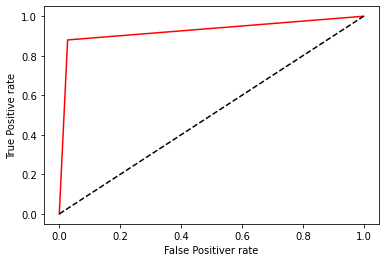

```
roc auc score:0.9263972773463715
```

```python
# roc curve
fpr, tpr, thresholds = roc_curve(np.argmax(train_y_onehot, axis=1),
                                 y_hat_predictions_label)
plt.plot(fpr, tpr, 'r-')
plt.plot([0,1], [0,1], 'k--')
plt.xlabel('False Positiver rate')
plt.ylabel('True Positive rate')
plt.show()

#auc score
print("\nroc auc score:" + str(roc_auc_score(np.argmax(train_y_onehot, axis=1), y_hat_predictions_label)))
```

#### SVM

```python
svm_clf = SVC(kernel='rbf')
svm_clf.fit(train_x_standardized, train_y)
predictions = svm_clf.predict(train_x_standardized)
```

[output not shown]

```python
print('preformance on training data:')
print('   > accuracy:', accuracy_score(train_y, predictions))
print('   > precision:', precision_score(train_y, predictions))
print('   > f1_score:', f1_score(train_y, predictions))
print('   > balanced_accuracy:', balanced_accuracy_score(train_y, predictions))
```

[output not shown]

#### RandomForest

```python
rf_clf = RandomForestClassifier(n_jobs=-1)
rf_clf.fit(train_x_standardized, train_y)
predictions = rf_clf.predict(train_x_standardized)
```

```python
print('preformance on training data:')
print('   > accuracy:', accuracy_score(train_y, predictions))
print('   > precision:', precision_score(train_y, predictions))
print('   > f1_score:', f1_score(train_y, predictions))
print('   > balanced_accuracy:', balanced_accuracy_score(train_y, predictions))
```

```
preformance on training data:
   > accuracy: 0.9876543209876543
   > precision: 0.9853372434017595
   > f1_score: 0.9838945827232796
   > balanced_accuracy: 0.9866743361135077
```

### 加分題 1 -kaggle

請將訓練後的模型套用至 [Kaggle Titanic](https://www.kaggle.com/c/titanic/overview) `test.csv` 上，並上傳至 Kaggle 進行評分，**截圖**後**嵌入**至 `markdown` 區塊中。

```python
PATH_TEST = '/content/drive/MyDrive/機器深度學習導論/test.csv'
print(PATH_TEST)
```

```
/content/drive/MyDrive/機器深度學習導論/test.csv
```

```python
df_test = pd.read_csv(PATH_TEST)
passenger_id = [i for i in df_test.PassengerId]
df_test.head()
```

|  | PassengerId | Pclass | Name | Sex | Age | SibSp | Parch | Ticket | Fare | Cabin | Embarked |
| --- | --- | --- | --- | --- | --- | --- | --- | --- | --- | --- | --- |
| 0 | 892 | 3 | Kelly, Mr. James | male | 34.5 | 0 | 0 | 330911 | 7.8292 | NaN | Q |
| 1 | 893 | 3 | Wilkes, Mrs. James (Ellen Needs) | female | 47.0 | 1 | 0 | 363272 | 7.0000 | NaN | S |
| 2 | 894 | 2 | Myles, Mr. Thomas Francis | male | 62.0 | 0 | 0 | 240276 | 9.6875 | NaN | Q |
| 3 | 895 | 3 | Wirz, Mr. Albert | male | 27.0 | 0 | 0 | 315154 | 8.6625 | NaN | S |
| 4 | 896 | 3 | Hirvonen, Mrs. Alexander (Helga E Lindqvist) | female | 22.0 | 1 | 1 | 3101298 | 12.2875 | NaN | S |

```python
df_test_sex_embarked = df_test[['Sex', 'Embarked']]
df_test_sex_embarked_dummy = pd.get_dummies(df_test_sex_embarked)
df_test_sex_embarked_dummy.head()
```

|  | Sex_female | Sex_male | Embarked_C | Embarked_Q | Embarked_S |
| --- | --- | --- | --- | --- | --- |
| 0 | 0 | 1 | 0 | 1 | 0 |
| 1 | 1 | 0 | 0 | 0 | 1 |
| 2 | 0 | 1 | 0 | 1 | 0 |
| 3 | 0 | 1 | 0 | 0 | 1 |
| 4 | 1 | 0 | 0 | 0 | 1 |

```python
df_test_rest = df_test[['Pclass', 'Age', 'SibSp', 'Parch', 'Fare']]
df_test_rest.head()
```

|  | Pclass | Age | SibSp | Parch | Fare |
| --- | --- | --- | --- | --- | --- |
| 0 | 3 | 34.5 | 0 | 0 | 7.8292 |
| 1 | 3 | 47.0 | 1 | 0 | 7.0000 |
| 2 | 2 | 62.0 | 0 | 0 | 9.6875 |
| 3 | 3 | 27.0 | 0 | 0 | 8.6625 |
| 4 | 3 | 22.0 | 1 | 1 | 12.2875 |

```python
df_test = pd.concat([df_test_sex_embarked_dummy, df_test_rest], axis=1)
cols = [i for i in df_test.columns]
df_test.head()
```

|  | Sex_female | Sex_male | Embarked_C | Embarked_Q | Embarked_S | Pclass | Age | SibSp | Parch | Fare |
| --- | --- | --- | --- | --- | --- | --- | --- | --- | --- | --- |
| 0 | 0 | 1 | 0 | 1 | 0 | 3 | 34.5 | 0 | 0 | 7.8292 |
| 1 | 1 | 0 | 0 | 0 | 1 | 3 | 47.0 | 1 | 0 | 7.0000 |
| 2 | 0 | 1 | 0 | 1 | 0 | 2 | 62.0 | 0 | 0 | 9.6875 |
| 3 | 0 | 1 | 0 | 0 | 1 | 3 | 27.0 | 0 | 0 | 8.6625 |
| 4 | 1 | 0 | 0 | 0 | 1 | 3 | 22.0 | 1 | 1 | 12.2875 |

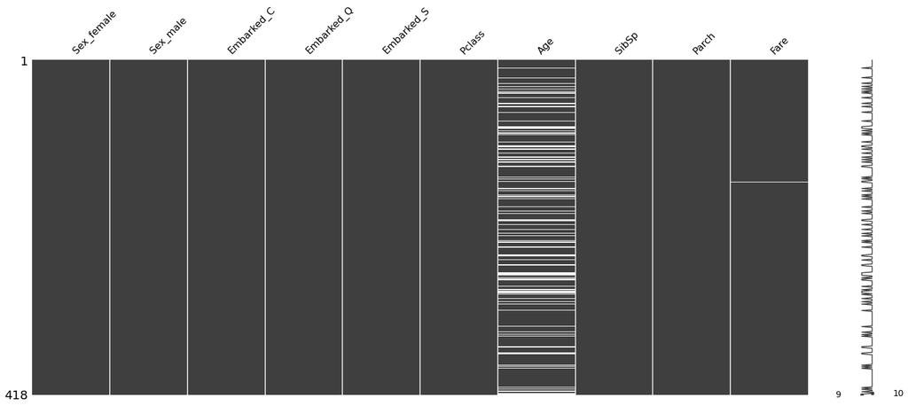

```python
msno.matrix(df_test)
```

```python
imputer = KNN(k=3)
df_test = pd.DataFrame(imputer.fit_transform(df_test), columns=cols)
df_test.head()
```

```
Imputing row 1/418 with 0 missing, elapsed time: 0.040
Imputing row 101/418 with 0 missing, elapsed time: 0.041
Imputing row 201/418 with 1 missing, elapsed time: 0.045
Imputing row 301/418 with 0 missing, elapsed time: 0.048
Imputing row 401/418 with 0 missing, elapsed time: 0.049
```

|  | Sex_female | Sex_male | Embarked_C | Embarked_Q | Embarked_S | Pclass | Age | SibSp | Parch | Fare |
| --- | --- | --- | --- | --- | --- | --- | --- | --- | --- | --- |
| 0 | 0.0 | 1.0 | 0.0 | 1.0 | 0.0 | 3.0 | 34.5 | 0.0 | 0.0 | 7.8292 |
| 1 | 1.0 | 0.0 | 0.0 | 0.0 | 1.0 | 3.0 | 47.0 | 1.0 | 0.0 | 7.0000 |
| 2 | 0.0 | 1.0 | 0.0 | 1.0 | 0.0 | 2.0 | 62.0 | 0.0 | 0.0 | 9.6875 |
| 3 | 0.0 | 1.0 | 0.0 | 0.0 | 1.0 | 3.0 | 27.0 | 0.0 | 0.0 | 8.6625 |
| 4 | 1.0 | 0.0 | 0.0 | 0.0 | 1.0 | 3.0 | 22.0 | 1.0 | 1.0 | 12.2875 |

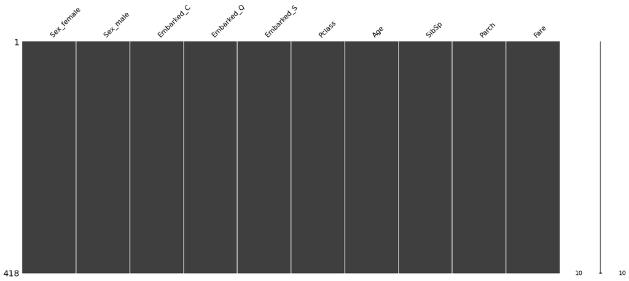

```python
msno.matrix(df_test)
```

```python
# features & target
test_x = df_test[['Sex_female', 'Sex_male', 'Embarked_C', 'Embarked_Q', 'Embarked_S', 'Pclass', 'Age', 'SibSp', 'Parch', 'Fare']]
test_x_standardized = StandardScaler().fit_transform(test_x)
```

```python
predictions_kaggle = np.argmax(network.predict(test_x), axis=1)
#predictions_kaggle
```

```python
df_upload = pd.DataFrame({
    'PassengerId': passenger_id,
    'Survived': predictions_kaggle
})

PATH_OUTPUT = '/content/drive/MyDrive/機器深度學習導論/output.csv'
df_upload.to_csv(PATH_OUTPUT)
```

score on kaggle:

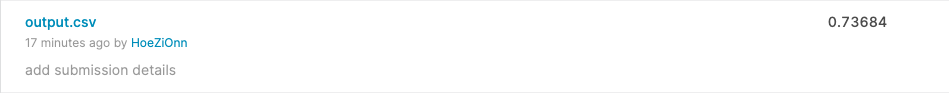

### 加分題 2 - 心得

請寫下完成本作業中所遇到的困難或是感想(字數不限)  
但請不要過於敷衍

在實作NN的時候才會發現其實自己以為還蠻了解的東西，自己實現起來也不太容易，而且在過程之中去尋找解答，需要參考更多的資訊。有時候反而覺得比起自己寫出東西，更難的是了解別人的東西。因為每一位作者實現的方法都不完全相同，需要知道哪個部分是自己所要找的，並將其消化為自己也能理解並寫出來。

而在使用模型的部分深深體會到助教的辛苦，不然事前把所有可能用到的code都對其做完整的說明，在完成作業的同時才不至於花太多的時間在尋找模型上的相關資訊。甚至在code與code之間都有實際例子參考，多虧助教們的用心讓我們在跑範例和完成作業的時候只要不出bug就可以順利完成大部分的事情。